# Rをつかってみよう

Kanazawa.R #1

伊東宏樹

2024-06-29

## はじめに

Kanazawa.R にご参加  
ありがとうございます。

## 自己紹介

- 氏名: 伊東宏樹
- 3月まで森林総合研究所勤務
- 4月から個人事業主（[伊東生態統計研究室](https://ito4303.sakura.ne.jp/)）
- データ解析、執筆・翻訳、研修講師などお引き受けいたします
- 出版物: 『[BUGSで学ぶ階層モデリング入門](https://www.kyoritsu-pub.co.jp/book/b10003729.html)』, 『[生態学のための階層モデリング](https://www.kyoritsu-pub.co.jp/book/b10003301.html)』（以上共訳）など

## 本日の内容

- Rの紹介
- Rをつかってみる（実演）
- さらに知るには

## “R”ってなに

[© 2016 The R Foundation, CC-BY-SA 4.0]

統計計算・グラフ作成向けのプログラミング言語&環境

## 特長

- 統計計算に特化した機能
  - パッケージが充実
- オープンソース
- 無料で使える
- コミュニティが充実
- だれでも参加できる

## なぜ“R”という名前なのか

最初の作者のファーストネーム (Robert Gentleman and Ross Ihaka) と、“S”言語から<sup>1</sup>

[^1]: https://cran.r-project.org/doc/FAQ/R-FAQ.html#Why-is-R-named-R_003f

## Rで できること

- 統計解析
- 機械学習
- データの操作・整形
- データの可視化
- などなど

## Rをつかっている人

- 学術
  - 医学・農学・生態学・心理学など
- 業務
  - IT系・医療系など
    - データ分析一般
      - なかでもマーケティング（広告効果等）
    - データ可視化（グラフ・ダッシュボード等）
    - 電子カルテサポートシステム（開業医）

## パッケージ

- 機能を拡張する関数やデータなどをまとめたもの
  - 各種の統計解析法
  - きれいなグラフ作成
  - YouTubeをみる<sup>1</sup>
  - などなど
- ユーザーが自分でパッケージを作れる
[^2]: https://github.com/kazutan/tubeplayR

## CRAN (Comprehensive R Archive Network)

- 「しーらん」または「くらん」
- 利用可能なパッケージのハブ
- 審査をとおるとCRANにパッケージが登録される
- 21019個のパッケージが登録されている（2024年6月29日現在）。
- 世界各地にミラーがある

## Rコミュニティ（日本国内）

- Tokyo.R, SappoRo.R, fukuoka.R など、各地で勉強会が開催されている。
- Japan.R
  - 各地のコミュニティがあつまるイベント

## R vs. Python

- 統計分析のパッケージはRの方が豊富
- 機械学習はPythonの方が充実

### [RとPythonは仲良し](https://github.com/izunyan/practice-py-r/blob/main/pdf/tokyor100_20220723_yawarakakujira_公開版.pdf)

- RからPythonを使える
  - Pythonが得意なところをPythonで処理させたりできる

## Rのインストール

CRANからインストーラーをダウンロード

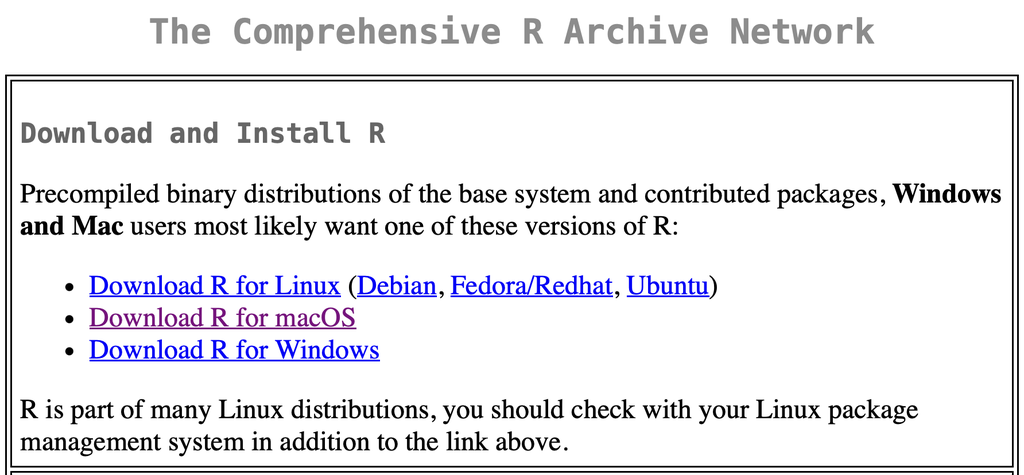

## WebR

Webブラウザで使えるR

Demo: https://webr.r-wasm.org/latest/

## Dockerイメージ

- [**rocker/rstudio**](https://hub.docker.com/r/rocker/rstudio)
  - RStudio（後述）環境
- [**rocker/tidyverse**](https://hub.docker.com/r/rocker/tidyverse)
  - RStudio + tidyverse （後述）環境
- [**rockerjp/tidyverse**](https://registry.hub.docker.com/r/rockerjp/tidyverse)
  - RStudio + tidyverse +日本語フォント

## R Commander

- GUI環境
- `install.packages("Rcmdr")` でインストール
  - macOSでは[XQuartz](https://www.xquartz.org/) (X11環境) のインストールが必要
- `library(Rcmdr)` で起動
  - macOSでは、XQuartzのxtermでRを起動して、そこからR Commanderを起動するのが確実

## RStudio

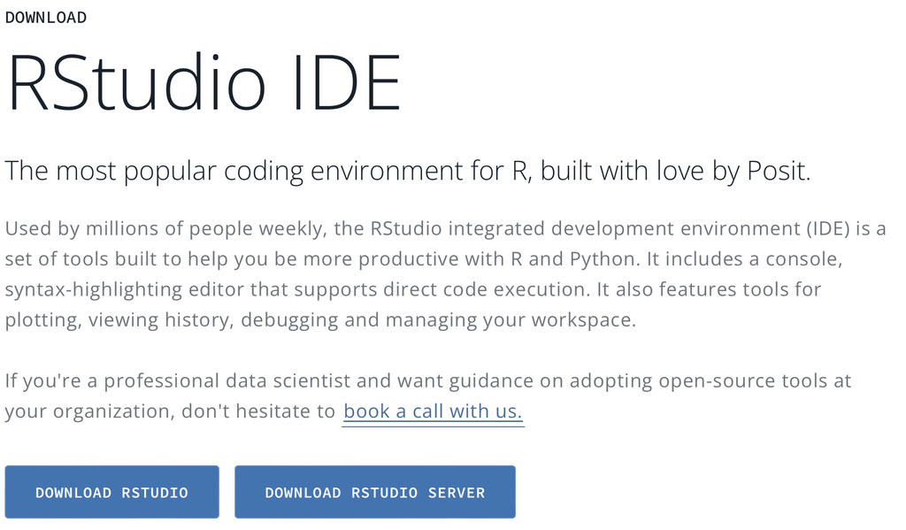

- R向け（Pythonも）統合開発環境 (IDE)
- RMarkdownやQuartoといったパブリッシングシステムもサポート
- ダウンロード https://posit.co/downloads/

## 実演

RStudioに移動します

## さらに知るには

### ネット上の情報源

公式メーリングリスト群（英語） (https://www.r-project.org/mail.html)

公式Mastodon（英語）https://fosstodon.org/tags/RStats

Tokyo.RのSlack (r-wakalang) https://r-wakalang.slack.com

mandaRa https://scrapbox.io/mandaRa/

### 図書

Rによる統計解析

- [Rで楽しむ統計](https://www.kyoritsu-pub.co.jp/book/b10003780.html)
  - 奥村晴彦著, 共立出版
- [Rで学ぶ統計的データ解析](https://www.kspub.co.jp/book/detail/5186190.html)
  - 林賢一・下平英寿著, 講談社

RStudioの使い方など

- [［改訂第2版］RユーザーのためのRStudio［実践］入門](https://gihyo.jp/book/2021/978-4-297-12170-9)
  - 松村優哉・湯谷啓明・紀ノ定保礼・前田和寛著, 技術評論社